# Supplementary Analysis: Excitatory Neuron Classification in Postnatal PsychAD Cells

Root-cause evaluation of low EN fraction in scANVI-integrated infant transcriptomes

Author

R.A. Dear

Published

May 25, 2026

## Background

In the integrated snRNAseq dataset combining Wang (2022), Velmeshev (2022; hereafter Vel), and PsychAD (Mathys 2023), scANVI-based label transfer assigns approximately 5% of PsychAD infant (<1 year) cells to the Excitatory (EN) class. By contrast, Wang and Vel cells from the same developmental window carry EN fractions of ~25% and ~30%, respectively. Given that the prefrontal cortex is characterised by substantial excitatory neuron populations at birth (*in utero* EN migration is largely complete by mid-gestation), a 5-fold deficit raises the question of whether the low EN fraction reflects (i) genuine biological differences in the PsychAD cohort, (ii) a technical or normalisation artefact, or (iii) a misclassification error arising from the integration model.

This supplementary analysis applies a series of orthogonal marker-based diagnostics to the raw, unnormalised count matrices of each source. The principal conclusion is that the EN fraction in PsychAD infants is genuinely low relative to Wang/Vel — partly reflecting a biological signature of early postnatal EN immaturity — but is further suppressed by a label-transfer artefact caused by the dominance of 453,000 adult PsychAD cells in the scANVI supervision signal.

## 1 Hypothesis H9 Rejected: Library Depth and HVG Selection Are Not Confounders

### 1.1 Per-cell library depth

A straightforward confound would arise if PsychAD cells have systematically lower UMI counts than Wang/Vel, causing EN markers to fall below detection thresholds under CPM normalisation. We examined total UMI depth for the matched <1 year subsets from each source.

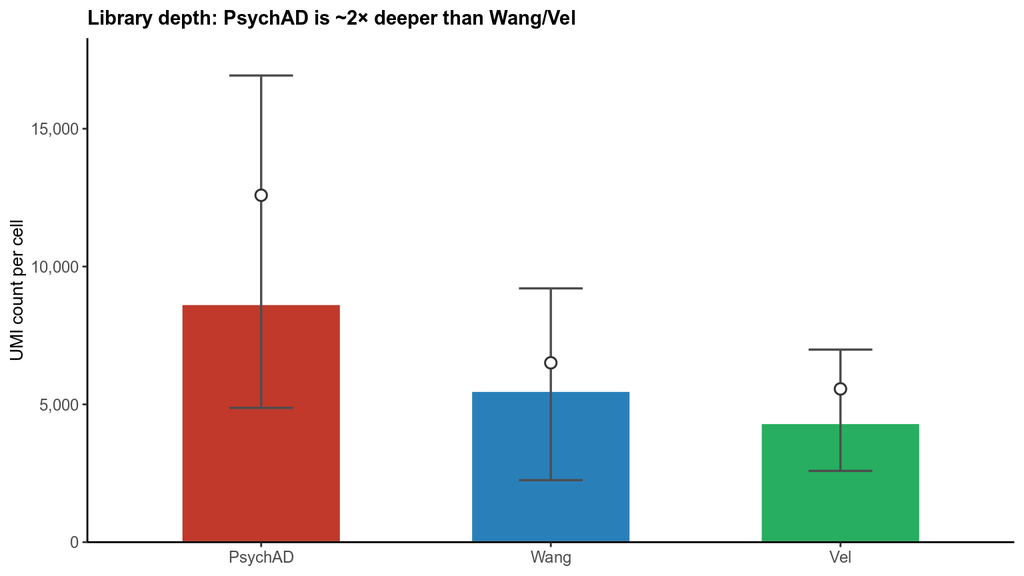

```r
qc <- read_csv(file.path(BASE, "hvg_intersection_v2", "per_cell_qc.csv"), show_col_types = FALSE) |>
  mutate(
    group_label = recode(group,
      "PSYCHAD" = "PsychAD",
      "WANG"    = "Wang",
      "VEL"     = "Vel"
    ),
    group_label = factor(group_label, levels = c("PsychAD", "Wang", "Vel"))
  )

p_depth <- ggplot(qc, aes(x = group_label, fill = group_label)) +
  geom_col(aes(y = total_counts_median), colour = "white", width = 0.55) +
  geom_errorbar(
    aes(ymin = total_counts_P25, ymax = total_counts_P75),
    width = 0.22, linewidth = 0.6, colour = "grey30"
  ) +
  geom_point(aes(y = total_counts_mean), shape = 21, fill = "white",
             colour = "grey20", size = 2.5, stroke = 0.8) +
  scale_fill_manual(values = GROUP_COLORS, guide = "none") +
  scale_y_continuous(
    labels = label_comma(),
    expand = expansion(mult = c(0, 0.08))
  ) +
  labs(
    x     = NULL,
    y     = "UMI count per cell",
    title = "Library depth: PsychAD is ~2× deeper than Wang/Vel"
  ) +
  theme_pub()

p_depth
```

PsychAD infant cells have a median of **8,636 UMI/cell** (mean 12,587), compared with 5,486 (mean 6,508) for Wang and 4,319 (mean 5,560) for Vel. Because CPM normalisation scales expression *inversely* with library size, deeper PsychAD libraries would, if anything, *reduce* normalised marker counts per unit of genuine expression — making this hypothesis untenable in the direction that would inflate IN relative to EN.